# Customizing Plots

Because `concurve` graphs functions via `ggplot2`, it is quite easy to customize parts of the plot beyond some of the arguments that are provided in the `ggcurve()` function. For example, we are able to provide arguments to the function to give custom titles, subtitles, x-axes, y-axes, fills, and colors. However, we could also do this using the standard `ggplot2` grammar. We’ll generate a quick graph to show how.

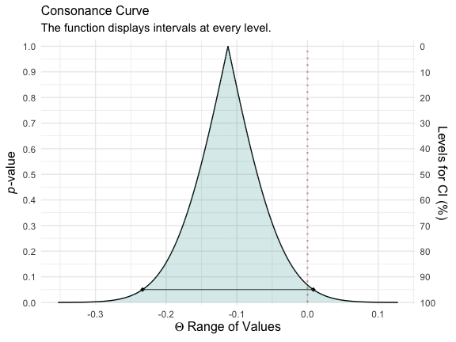

```r
library(concurve)
set.seed(1031)
GroupA <- rnorm(500)
GroupB <- rnorm(500)
RandomData <- data.frame(GroupA, GroupB)
intervalsdf <- curve_mean(GroupA, GroupB,
  data = RandomData, method = "default"
)
(function1 <- ggcurve(data = intervalsdf[[1]], type = "c", nullvalue = TRUE))
```

Those are some of the default options provided to `ggcurve()`. We could provide `ggcurve()` arguments for the title, subtitle, etc, but we could also do it like so:

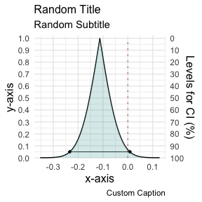

```r
library(ggplot2)
function1 +
  labs(
    title = "Random Title",
    subtitle = "Random Subtitle",
    x = "x-axis",
    y = "y-axis",
    caption = "Custom Caption"
  )
```

If we even wanted to provide a custom theme, we could do the following.

[figure not shown]

```r
library(cowplot)
logo_file <- "https://res.cloudinary.com/less-likely/image/upload/v1575441662/Site/Logo2.jpg"

function1 <- function1 +
  theme_cowplot()

function2 <- ggdraw(function1) +
  draw_image(logo_file, x = 1, y = 1, hjust = 2, vjust = 1.75, width = 0.13, height = 0.2)

function2
```

I’ve only tried testing this with the `cowplot` package, so I cannot say for sure that the functions won’t break when applied with other themes.<sup>1</sup>

# Saving Plots

The most common way useRs save plots is by going to the plots tab in an IDE like RStudio and clicking “export” and then “save as image” or by using `ggsave()`, however, `cowplot` has a superior function with far better default options built into it known as `save_plot()`.

```r
save_plot("function2.pdf", function2)
```

# References

1. Wilke CO. *Cowplot: Streamlined Plot Theme and Plot Annotations for “Ggplot2”*.; 2019. https://CRAN.R-project.org/package=cowplot.